# Week 9: Multivariate linear regression

Tristan Muno

November 18, 2026

## Week 9 goals

By the end of today, you will be able to:

1. Explain **Simpson’s paradox**: why an association in pooled data can point the opposite way from the association within groups.
2. Say what **controlling for a variable** does, with Venn diagrams of shared variation, and read each coefficient as a **partial association**, including a **dummy variable**.
3. Use a **DAG** to justify control variables, and recognise controls that do harm.
4. Compare models by how well they predict new data, using **leave-one-out cross-validation (LOO)**.
5. Report several models in one **regression table**, built with `broom.mixed` and `kable()`.

## Today

1. **A puzzle:** does education pay?
2. **What controlling means**, in circles
3. **Which controls**, in arrows
4. **The eight steps, two models**, with a new stop: comparing models
5. **Reporting:** a regression table and three quantities of interest

**Note**

**One effect per predictor, the same for everyone.** Today every predictor shifts the outcome by the same amount for everyone. Whether an effect differs between groups is next week’s question: interactions.

## Where today fits

Last week: one predictor, all eight steps. Today: **several predictors**, so steps 1, 3 and 7 get harder, and a comparison of models enters before step 7.

Table 1: The 8-step Bayesian workflow. Every homework exercises the steps introduced so far, cumulatively, and the exam runs all eight end to end.

| # | Step | What you produce |
| --- | --- | --- |
| 1 | **Estimand** | The quantity you want to learn about, stated precisely as a target before any model is fitted. |
| 2 | **Data summary** | The data described: measurement, coverage, obvious issues. |
| 3 | **Formal model** | Likelihood and priors written down, the generative model. |
| 4 | **Prior predictive check** | Simulate from the priors, confirm they imply plausible data. |
| 5 | **Fit** | Estimate with `brms`, weakly-informative priors by default. |
| 6a | **MCMC diagnostics** | R-hat, ESS, divergences, trace plots. Did sampling work? |
| 6b | **Posterior predictive check** | Does the fitted model reproduce key features of the data? |
| 7 | **Interpretation** | Answer the estimand on the outcome scale, with uncertainty. |
| 8 | **Limitations** | What the analysis can and cannot support, threats and next steps. |

# A puzzle

## Does education pay?

We have survey data on 200 working adults: years of schooling and annual income, in thousand EUR.

> **Q:** Predict the sign: does a person with more schooling earn more or less, on average?

**View source**

```r
ggplot(income, aes(x = education, y = income)) +
  geom_point(colour = "grey40", alpha = 0.6, size = 1.8) +
  geom_smooth(method = "lm", se = FALSE, colour = col_3, linewidth = 1.2) +
  theme_classic() +
  labs(
    x = "Years of schooling",
    y = "Annual income (thousand EUR)",
    title = "More schooling, less income?"
  )
```

[figure not shown]

Figure 1: Annual income against years of schooling for all 200 people, with the least-squares line drawn for the eye. In the pooled data, people with more schooling earn less.

## Should you drop out?

In the pooled data, every extra year of schooling goes with **1.5 thousand EUR less** income.

> **Q:** Would you advise a friend to leave school early?

**View source**

```r
ggplot(income, aes(x = education, y = income, colour = gender)) +
  geom_point(alpha = 0.6, size = 1.8) +
  geom_smooth(method = "lm", se = FALSE, linewidth = 1.2) +
  scale_colour_manual(values = gender_cols) +
  theme_classic() +
  labs(
    x = "Years of schooling",
    y = "Annual income (thousand EUR)",
    colour = NULL,
    title = "Within each group, schooling pays"
  )
```

[figure not shown]

Figure 2: The same 200 people, coloured by gender, with one least-squares line per group. Within each gender, more schooling goes with more income. The pooled line of the previous figure runs the other way.

## Simpson’s paradox

An association in the pooled data can **reverse** inside every group. This is **Simpson’s paradox** (Simpson 1951; Pearl et al. 2016).

Why here?

- In these data, **women have 4.2 more years of schooling** than men on average.
- And **women earn less** than men with the same schooling, a gap of 19 thousand EUR.

So gender is related to **both** schooling and income, and the pooled line mixes the two.

Two questions follow:

1. **Venn diagrams:** what does it mean to “hold gender constant”?
2. **DAGs:** how do we know *which* variables to hold constant?

# What controlling means

## Shared variation

**View source**

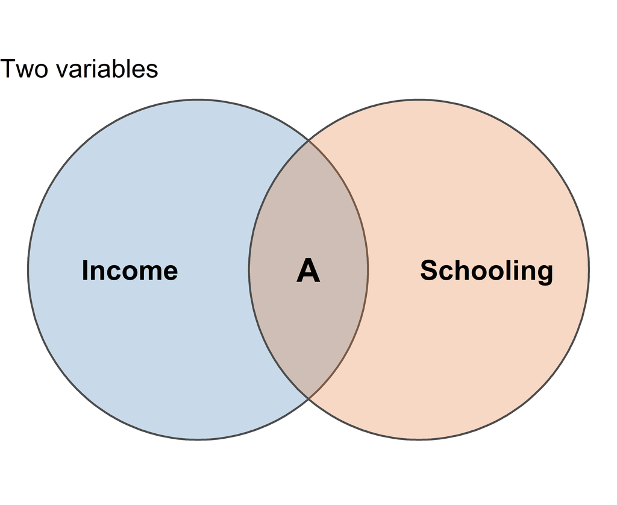

Figure 3: Each circle stands for the variation of one variable across people. The overlap is the variation income and schooling share, and it is what the bivariate slope learns from.

```r
tibble(
  name = c("Income", "Schooling"),
  x0 = c(0, 1.3),
  y0 = c(0, 0),
  r = 1,
  lx = c(-0.4, 1.7),
  ly = c(0, 0),
  fill = c(col_1, col_2)
) |>
  draw_venn(
    regions = tibble(x = 0.65, y = 0, label = "A"),
    title = "Two variables"
  )
```

- Each **circle** is the variation of one variable: how much people differ on it.
- The **overlap A** is variation the two share.
- The bivariate model learns its slope from **A**, and only from **A** (Kennedy 1981).

> **Q:** Gender is related to both, so where would its circle go?

## Adding a control

**View source**

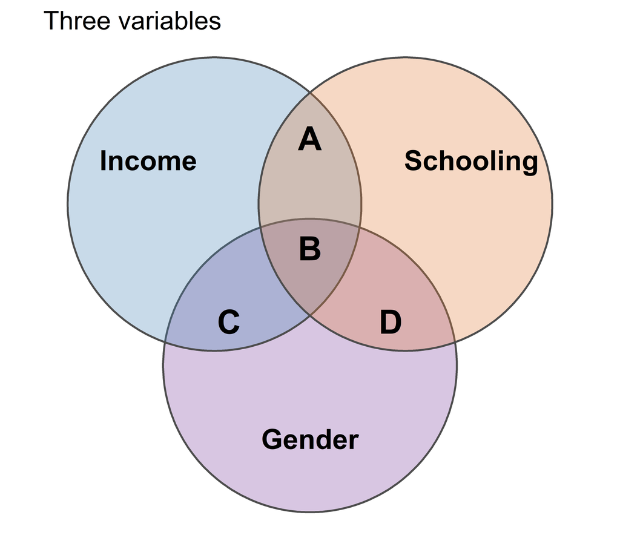

Figure 4: Gender added as a third circle. Region B is variation all three share. The naive model credits A and B to schooling, the controlled model learns the schooling slope from A only.

```r
venn_three <- tibble(
  name = c("Income", "Schooling", "Gender"),
  x0 = c(0, 1.3, 0.65),
  y0 = c(0, 0, -1.1),
  r = 1,
  lx = c(-0.45, 1.75, 0.65),
  ly = c(0.3, 0.3, -1.6),
  fill = c(col_1, col_2, col_3)
)
draw_venn(
  venn_three,
  regions = tibble(
    x = c(0.65, 0.65, 0.1, 1.2),
    y = c(0.45, -0.3, -0.8, -0.8),
    label = c("A", "B", "C", "D")
  ),
  title = "Three variables"
)
```

Table 2: The regions of Figure 4 and which model uses each to learn the schooling slope.

| Region | Shared by | Used for the schooling slope by |
| --- | --- | --- |
| A | income, schooling | both models |
| B | all three | the naive model only |
| C | income, gender | neither |
| D | schooling, gender | neither |

**Controlling for gender** means learning the schooling slope from variation that gender does not share. In Figure 2: comparing people **within one colour**.

## When controls overlap

> **Q:** What if the schooling and gender circles overlapped almost completely?

**View source**

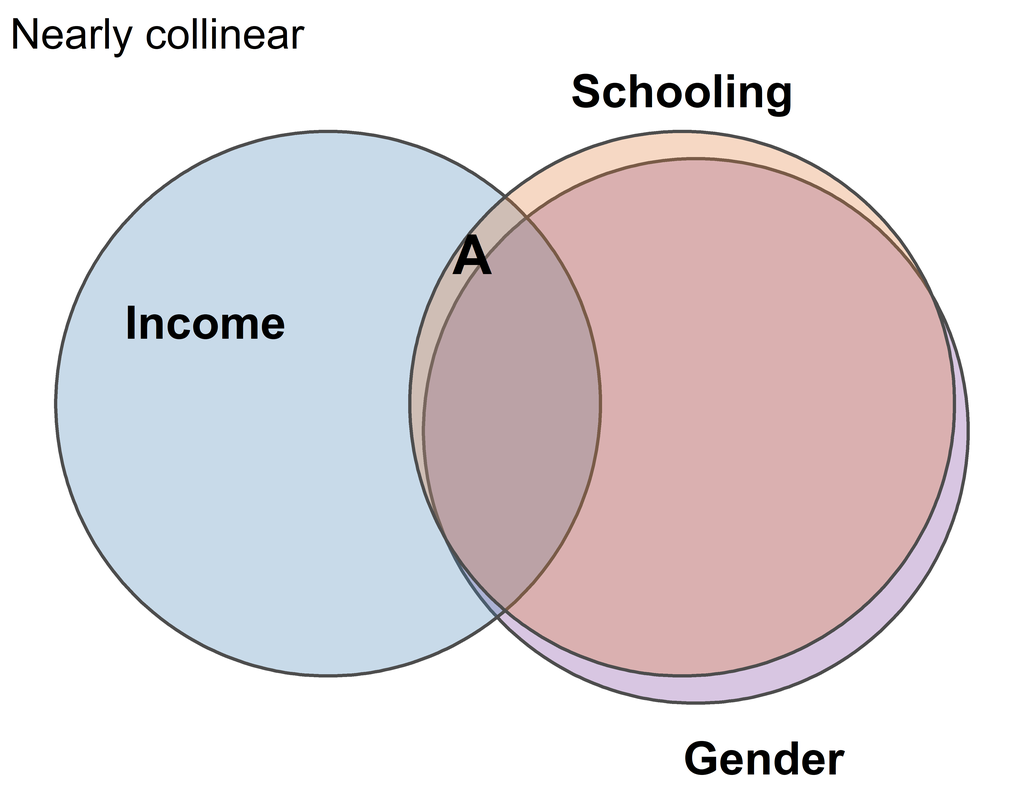

Figure 5: Schooling and gender almost coincide. Little variation in schooling is left that gender does not share, so region A, the information about the schooling slope, is tiny.

```r
tibble(
  name = c("Income", "Schooling", "Gender"),
  x0 = c(0, 1.3, 1.35),
  y0 = c(0, 0, -0.1),
  r = 1,
  lx = c(-0.45, 1.3, 1.6),
  ly = c(0.3, 1.15, -1.3),
  fill = c(col_1, col_2, col_3)
) |>
  draw_venn(
    regions = tibble(x = 0.53, y = 0.55, label = "A"),
    title = "Nearly collinear"
  )
```

- Region A is tiny, so the data say **little** about the schooling slope, and its posterior is **wide**.
- In full overlap, A vanishes: the slope cannot be learned at all.
- This is **A4, no perfect collinearity**, from the recap, which only bites once there are several predictors.

**Note**

**The circles show which variation a coefficient uses, nothing more.** They cannot show signs, so they cannot show the reversal itself. Which circles belong in the model at all is a question for theory: DAGs.

# Which controls

## A DAG organises the theory

- A **directed acyclic graph (DAG)** writes down what we *theorise* before we write the model (McElreath 2020).
- **Nodes** are variables, **arrows** say which variable influences which.
- A DAG says **whether** and in **which direction**, not **how**: no shape, no size, no sign.
- **Acyclic:** no path leads back to where it started.

**View source**

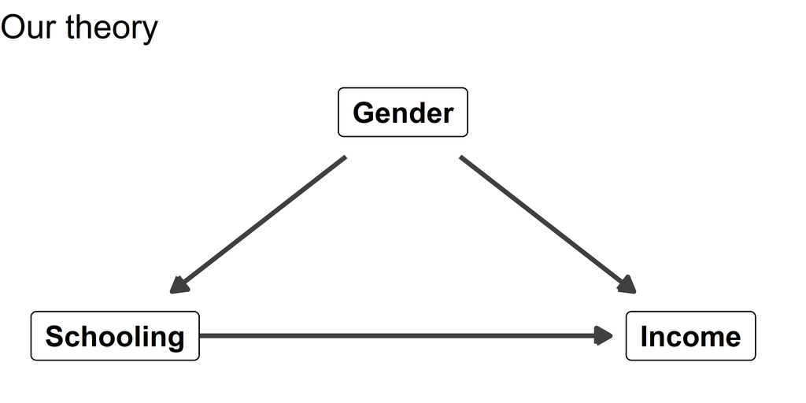

Figure 6: Our theory as a DAG: gender influences schooling and income, and schooling influences income.

```r
draw_dag(
  nodes = tibble(
    name = c("G", "E", "I"),
    x = c(1, 0, 2),
    y = c(1, 0, 0),
    label = c("Gender", "Schooling", "Income")
  ),
  edges = tibble(from = c("G", "G", "E"), to = c("E", "I", "I")),
  title = "Our theory"
)
```

**Tip**

**Draw the DAG first, then formalise.** Every arrow into the outcome becomes a term at step 3, and the model decides how large.

## Three ways variables connect

**View source**

```r
dag_fork <- draw_dag(
  tibble(
    name = c("Z", "X", "Y"),
    x = c(1, 0, 2),
    y = c(1, 0, 0),
    label = c("Z", "X", "Y")
  ),
  tibble(from = c("Z", "Z"), to = c("X", "Y")),
  title = "Fork: Z is a confounder"
)
dag_pipe <- draw_dag(
  tibble(
    name = c("X", "M", "Y"),
    x = c(0, 1, 2),
    y = 0,
    label = c("X", "M", "Y")
  ),
  tibble(from = c("X", "M"), to = c("M", "Y")),
  title = "Pipe: M is a mediator"
)
dag_collider <- draw_dag(
  tibble(
    name = c("X", "Y", "C"),
    x = c(0, 2, 1),
    y = c(1, 1, 0),
    label = c("X", "Y", "C")
  ),
  tibble(from = c("X", "Y"), to = c("C", "C")),
  title = "Collider: C is caused by both"
)
dag_fork | dag_pipe | dag_collider
```

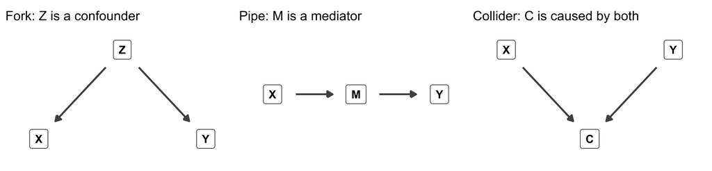

Figure 7: The three basic structures. In a fork, Z is a common cause of X and Y. In a pipe, X influences Y through M. In a collider, X and Y both influence C.

Table 3: Whether to control for the middle variable of each structure in Figure 7.

| Structure | Control for the middle variable? | Why |
| --- | --- | --- |
| Fork (confounder) | **Yes** | Otherwise its influence is credited to X |
| Pipe (mediator) | **Usually not** | It removes part of the association we want |
| Collider | **Never** | It creates an association that is not there |

> **Q:** Which structure is gender in our story, and which is the job someone holds (occupation)?

## Collider bias: a control that lies

**View source**

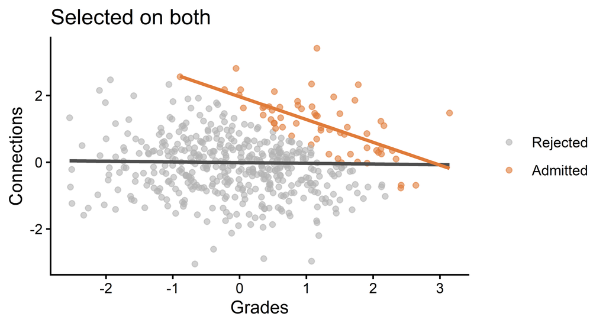

Figure 8: Five hundred simulated applicants. Grades and connections are unrelated overall (grey line), but negatively related among the admitted (orange).

```r
ggplot(applicants, aes(x = grades, y = connections)) +
  geom_point(aes(colour = admitted), alpha = 0.6, size = 1.4) +
  geom_smooth(method = "lm", se = FALSE, colour = "grey30") +
  geom_smooth(
    data = filter(applicants, admitted),
    method = "lm",
    se = FALSE,
    colour = col_2
  ) +
  scale_colour_manual(
    values = c(`FALSE` = "grey70", `TRUE` = col_2),
    labels = c("Rejected", "Admitted")
  ) +
  theme_classic() +
  labs(
    x = "Grades",
    y = "Connections",
    colour = NULL,
    title = "Selected on both"
  )
```

An elite programme admits on good **grades** or good **connections**, unrelated in the population.

- All applicants: correlation **-0.02**.
- Admitted only: correlation **-0.64**.

Admission is a **collider**:

grades $\rightarrow$ admitted $\leftarrow$ connections

Controlling for it creates the association.

**Important**

**Every control variable is a claim, and it needs a justification.** More controls are not safer: a mediator removes part of the association you want, a collider invents one.

# The eight steps, two models

## Step 1: Estimand

The research question:

> Is schooling associated with income, among people of the same gender?

What precisely do we want to learn?

> How much higher, on average, is the income of a person with one more year of schooling, **compared with a person of the same gender**?

That is a **partial association**: a slope that holds gender constant. The controls are part of the estimand, so they are chosen here, at step 1, with the DAG.

**Warning**

**A partial association is still not a causal effect.** It is a causal effect only if the DAG is right and complete, and the data cannot check that. Ability, family background or field of study could all still be missing.

## Step 2: Data summary

```r
income |>
  group_by(gender) |>
  summarise(
    n = n(),
    schooling = mean(education),
    income = mean(income)
  ) |>
  knitr::kable(
    digits = 1,
    col.names = c("Gender", "People", "Schooling (years)", "Income (thousand EUR)")
  )
```

Table 4: Number of people, mean years of schooling and mean annual income by gender. Women have more schooling on average, and a lower average income.

| Gender | People | Schooling (years) | Income (thousand EUR) |
| --- | --- | --- | --- |
| Man | 112 | 12.1 | 37.8 |
| Woman | 88 | 16.3 | 25.8 |

## Step 2: One variable at a time

**View source**

```r
income |>
  select(gender, education, income) |>
  pivot_longer(
    c(education, income),
    names_to = "variable",
    values_to = "value"
  ) |>
  mutate(
    variable = case_match(
      variable,
      "education" ~ "Years of schooling",
      "income" ~ "Annual income (thousand EUR)"
    ),
    variable = fct_relevel(variable, "Years of schooling")
  ) |>
  ggplot(aes(x = value, fill = gender)) +
  geom_histogram(
    bins = 20,
    position = "identity",
    alpha = 0.5,
    colour = "white"
  ) +
  facet_wrap(~variable, scales = "free") +
  scale_fill_manual(values = gender_cols) +
  theme_classic() +
  labs(
    x = NULL,
    y = "People",
    fill = NULL,
    title = "Schooling and income, by gender"
  )
```

[figure not shown]

Figure 9: Years of schooling and annual income, one histogram per gender. Women have more schooling and a lower income, so each variable consists of two shifted groups.

> **Q:** What does gender do to each distribution?

Together with Figure 2: schooling and income rise together **within** each gender, and gender is related to **both**.

## Step 3: Formal model

**1. Outcome distribution.** Income is drawn from a normal distribution with mean $\mu_i$ and standard deviation $\sigma$:

$$y_i \sim \mathcal{N}(\mu_i, \sigma)
\tag{1}$$

**2. Linear predictor.** The mean is a straight line in schooling, shifted by gender:

$$\mu_i = \alpha + \beta_1 x_{i1} + \beta_2 x_{i2}
\tag{2}$$

- $y_i$ is the income of person $i$, in thousand EUR.
- $x_{i1}$ is their years of schooling **minus 12**, so 0 means 12 years and 4 means 16 years.
- $x_{i2}$ is 1 for a woman and 0 for a man.
- The **naive model** is the same, without $\beta_2 x_{i2}$.

Read $\sim$ as **is drawn from** (random) and $=$ as **is defined as** (fixed).

$\beta_1$ is a **partial association**: the difference in expected income between two people of the **same gender** whose schooling differs by one year.

## Step 3: Why subtract 12?

The intercept $\alpha$ is the expected income when **every predictor is 0**.

Table 5: Years of schooling and the centred predictor $x_{i1}$, which subtracts 12.

| Years of schooling | $x_{i1}$ |
| --- | --- |
| 8 | $-4$ |
| 12 | 0 |
| 16 | 4 |
| 20 | 8 |

- With plain years, $x_{i1} = 0$ would be a person with **no schooling at all**, far outside our data.
- Centred at 12, $x_{i1} = 0$ is a person with **12 years**, so $\alpha$ is the expected income of a man with 12 years of schooling.

**Note**

**Centring moves only the intercept.** The slope $\beta_1$ stays the same, and now $\alpha$ is a value we can defend a prior for.

## Step 3: A dummy variable

$x_{i2}$ is a **dummy variable**: 1 for women, 0 for men, the **reference group**.

- Men: $\mu_i = \alpha + \beta_1 x_{i1}$
- Women: $\mu_i = (\alpha + \beta_2) + \beta_1 x_{i1}$

$\beta_2$ **shifts the line**: the expected income gap between a woman and a man with the same schooling.

**View source**

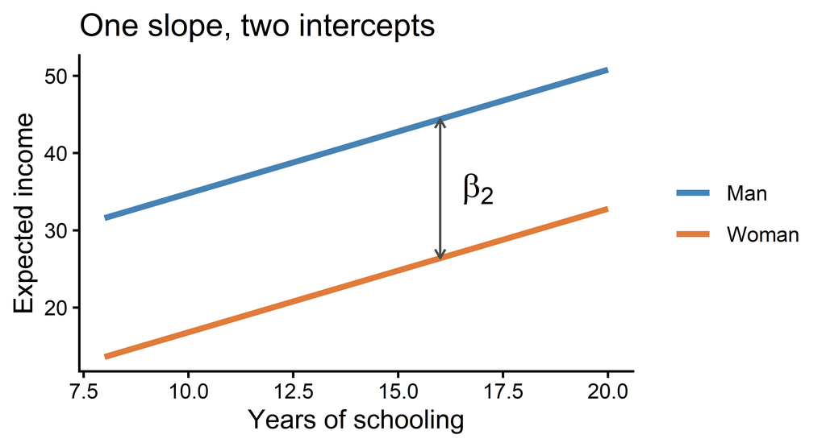

Figure 10: What the linear predictor of the controlled model implies, with illustrative values. The dummy shifts the line for women by beta 2. Both lines share the slope beta 1.

```r
expand_grid(education = c(8, 20), gender = c("Man", "Woman")) |>
  mutate(
    mu = 38 + 1.6 * (education - 12) - 18 * (gender == "Woman")
  ) |>
  ggplot(aes(x = education, y = mu, colour = gender)) +
  geom_line(linewidth = 1.2) +
  annotate(
    "segment",
    x = 16,
    xend = 16,
    y = 38 + 1.6 * 4,
    yend = 38 + 1.6 * 4 - 18,
    arrow = arrow(ends = "both", length = unit(0.15, "cm")),
    colour = "grey30"
  ) +
  annotate("text", x = 16.9, y = 35.4, label = "beta[2]", parse = TRUE, size = 5) +
  scale_colour_manual(values = gender_cols) +
  theme_classic() +
  labs(
    x = "Years of schooling",
    y = "Expected income",
    colour = NULL,
    title = "One slope, two intercepts"
  )
```

**Important**

**The lines are parallel because the model says so.** Whether schooling pays off differently for women and men is next week: interactions.

## Step 3: The posterior

**3. Posterior, proportional form.**

$$P(\alpha, \beta_1, \beta_2, \sigma \mid \mathbf{y}, \mathbf{X}) \propto \mathcal{L}(\alpha, \beta_1, \beta_2, \sigma \mid \mathbf{y}, \mathbf{X}) \times P(\alpha) \, P(\beta_1) \, P(\beta_2) \, P(\sigma)
\tag{3}$$

- $\mathbf{y}$ is the income column, and $\mathbf{X}$ holds the two predictor columns, $\mathbf{x}_1$ (schooling) and $\mathbf{x}_2$ (gender), 200 rows each.
- The likelihood $\mathcal{L}$ comes from Equation 1 and Equation 2, applied to every person.

The left side lists every unknown: **four parameters, so four priors** to choose. The naive model has three.

## Step 3: The complete model

$$\begin{aligned}
y_i &\sim \mathcal{N}(\mu_i, \sigma) && \text{outcome distribution} \\
\mu_i &= \alpha + \beta_1 x_{i1} + \beta_2 x_{i2} && \text{linear predictor} \\
\alpha &\sim \mathcal{N}(35, 10) && \text{prior} \\
\beta_1 &\sim \mathcal{N}(0, 3) && \text{prior} \\
\beta_2 &\sim \mathcal{N}(0, 10) && \text{prior} \\
\sigma &\sim \text{Exponential}(0.1) && \text{prior}
\end{aligned}
\tag{4}$$

Every prior is argued on the scale of the outcome, thousand EUR per year:

**The intercept, $\alpha \sim \mathcal{N}(35, 10)$**

**Note**

**The expected income of a man with 12 years of schooling.** Typical full-time incomes lie in the tens of thousands, so the prior is centred on 35. With 95 percent probability it lies between 15 and 55.

**The schooling slope, $\beta_1 \sim \mathcal{N}(0, 3)$**

**Note**

**Centred on no association, because the sign is what we want to learn.** An extra year of schooling could plausibly shift income by a few thousand EUR. 95 percent of the prior lies between $-6$ and $+6$.

**The gender dummy, $\beta_2 \sim \mathcal{N}(0, 10)$**

**Note**

**Centred on no gap, open in both directions.** A gap of 20 thousand EUR at the same schooling would be very large. 95 percent of the prior lies between $-20$ and $+20$.

**The residual standard deviation, $\sigma \sim \text{Exponential}(0.1)$**

**Note**

**Positive, and typically around 10.** An exponential with rate 0.1 has a mean of 10 thousand EUR, so people typically lie that far from their expected income, and smaller values are more plausible than larger ones.

The naive model uses the same priors for $\alpha$, $\beta_1$ and $\sigma$.

## Step 4: Prior predictive check

**View source**

```r
set.seed(2026)
tibble(
  draw = 1:50,
  alpha = rnorm(50, 35, 10),
  beta_1 = rnorm(50, 0, 3),
  beta_2 = rnorm(50, 0, 10)
) |>
  expand_grid(education = c(8, 20), gender = c("Man", "Woman")) |>
  mutate(
    mu = alpha + beta_1 * (education - 12) + beta_2 * (gender == "Woman")
  ) |>
  ggplot(aes(x = education, y = mu, group = draw)) +
  geom_hline(yintercept = 0, linetype = "dashed", colour = "grey50") +
  geom_line(colour = col_3, alpha = 0.3) +
  facet_wrap(~gender) +
  theme_classic() +
  labs(
    x = "Years of schooling",
    y = "Expected income (thousand EUR)",
    title = "Average worlds our priors consider possible"
  )
```

[figure not shown]

Figure 11: Fifty lines per gender drawn from the priors of the controlled model. The priors allow rising and falling lines and gaps in both directions, all within a broadly plausible range of incomes.

## Step 5: Fit both models

```r
income <- income |> mutate(edu12 = education - 12) # centre at 12 years

shared_priors <- c(
  prior(normal(35, 10), class = "b", coef = "Intercept"),
  prior(normal(0, 3), class = "b", coef = "edu12"),
  prior(exponential(0.1), class = "sigma")
)

fit_naive <- brm(
  income ~ 0 + Intercept + edu12,
  data = income,
  prior = shared_priors,
  seed = 2026,
  refresh = 0,
  file = here("website", "slides", "data", "week09-fit-naive"),
  file_refit = "on_change"
)
```

```r
fit_gender <- brm(
  income ~ 0 + Intercept + edu12 + woman,
  data = income,
  prior = c(shared_priors, prior(normal(0, 10), class = "b", coef = "woman")),
  seed = 2026,
  refresh = 0,
  file = here("website", "slides", "data", "week09-fit-gender"),
  file_refit = "on_change"
)

fit_naive <- add_criterion(fit_naive, "loo")
fit_gender <- add_criterion(fit_gender, "loo")
```

## Step 6a: MCMC diagnostics

**View source**

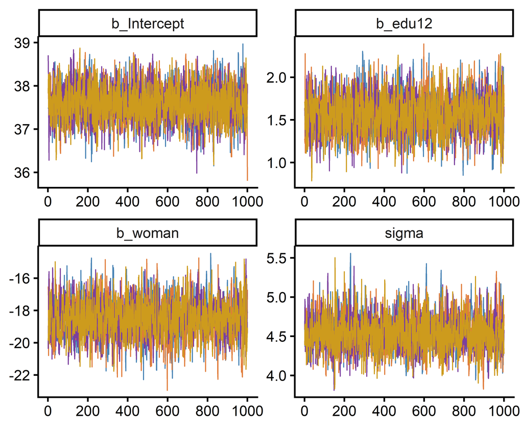

Figure 12: Trace plots for the model controlling for gender, four chains per parameter. The chains overlap and wander around the same region.

```r
mcmc_plot(fit_gender, type = "trace", facet_args = list(ncol = 2)) +
  scale_colour_manual(values = chain_cols) +
  theme_classic() +
  theme(legend.position = "none")
```

```r
summary(fit_gender)
```

```
 Family: gaussian
  Links: mu = identity
Formula: income ~ 0 + Intercept + edu12 + woman
   Data: income (Number of observations: 200)
  Draws: 4 chains, each with iter = 2000; warmup = 1000; thin = 1;
         total post-warmup draws = 4000

Regression Coefficients:
          Estimate Est.Error l-95% CI u-95% CI Rhat Bulk_ESS Tail_ESS
Intercept    37.60      0.44    36.76    38.44 1.00     2982     2408
edu12         1.57      0.24     1.11     2.04 1.00     2388     2337
woman       -18.49      1.20   -20.89   -16.13 1.00     2148     2064

Further Distributional Parameters:
      Estimate Est.Error l-95% CI u-95% CI Rhat Bulk_ESS Tail_ESS
sigma     4.54      0.23     4.11     5.03 1.00     2305     2219

Draws were sampled using sample(hmc). For each parameter, Bulk_ESS
and Tail_ESS are effective sample size measures, and Rhat is the potential
scale reduction factor on split chains (at convergence, Rhat = 1).
```

Across both models: largest R-hat 1.003, smallest ESS 2064, 0 divergent transitions, so **no evidence of non-convergence**.

## Step 6b: Posterior predictive check

**View source**

```r
set.seed(2026)
ppc_naive <- pp_check(fit_naive, ndraws = 50) +
  theme_classic() +
  labs(x = "Income (thousand EUR)", title = "Naive model")
ppc_gender <- pp_check(fit_gender, ndraws = 50) +
  theme_classic() +
  labs(x = "Income (thousand EUR)", title = "Controlling for gender")
ppc_naive + ppc_gender + plot_layout(guides = "collect")
```

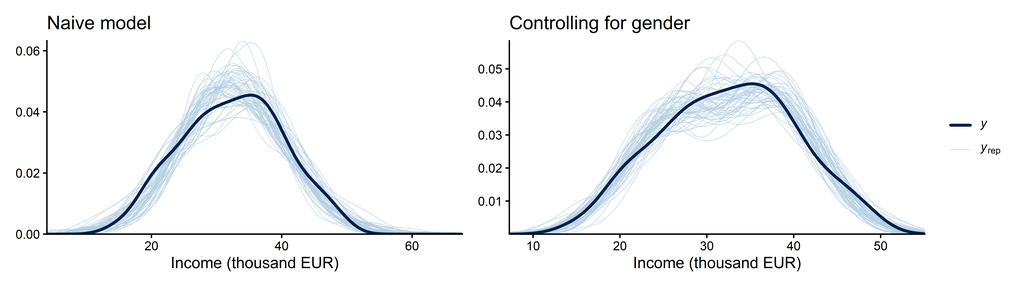

Figure 13: Posterior predictive checks. The dark line is the observed distribution of income, the pale lines are datasets generated by each fitted model. Both models reproduce the overall shape of income about equally well, so this check cannot tell them apart.

> **Q:** Which model generates data that look more like ours?

# Comparing models

## Which model fits better?

> **Q:** We have two fitted models, so how would you decide which fits the data better?
- Every extra predictor brings a model **closer to the data it was fitted on**, even a predictor that is pure noise.
- What we want: how well does the model predict **people it has not seen**?

## Leave-one-out cross-validation

**Leave-one-out cross-validation (LOO)** asks exactly that:

1. Leave out person $i$, and fit the model to everyone else.
2. Ask how plausible the model finds person $i$’s actual income.
3. Repeat for every person and add up:

$$\text{elpd}_{\text{loo}} = \sum_{i=1}^{n} \log p(y_i \mid \mathbf{y}_{-i})
\tag{5}$$

The **expected log predictive density (ELPD)**: higher is better. `loo()` approximates all $n$ refits from the one fit we already have (Vehtari et al. 2017).

## Comparing our two models

**View source**

```r
loo_compare(fit_gender, fit_naive) |>
  as_tibble() |>
  mutate(
    model = case_match(
      model,
      "fit_gender" ~ "Controlling for gender",
      "fit_naive" ~ "Naive"
    )
  ) |>
  select(model, elpd_diff, se_diff) |>
  knitr::kable(
    digits = 1,
    col.names = c("Model", "ELPD difference", "Standard error")
  )
```

Table 6: LOO comparison of the two models. The better model comes first, with a difference of zero. The second row gives how much lower its ELPD is, and the standard error of that difference.

| Model | ELPD difference | Standard error |
| --- | --- | --- |
| Controlling for gender | 0.0 | 0.0 |
| Naive | -82.9 | 9.6 |

- The naive model predicts worse by **82.9**, with a standard error of 9.6.
- A difference below about **4** is small, and beyond that we compare it with its standard error: here it is **9 standard errors**.
- Largest Pareto $k$: 0.23, below 0.7, so the approximation can be trusted.

## What LOO cannot tell you

> **Q:** In the admissions example, would a model predicting connections from grades **and admission** predict better than one from grades alone?

Yes: admission carries information about connections. And it would show a negative association between grades and connections that is not there.

**Important**

**LOO ranks how well models predict, not whether their controls are right.** A collider or a mediator can improve the ELPD and still bias the coefficient you care about. The DAG chooses the model for the estimand, and LOO checks how well it predicts.

# Step 7: Reporting

## Step 7: The raw output

Every report starts from the raw output, so get used to reading it.

```r
summary(fit_gender)
```

```
 Family: gaussian
  Links: mu = identity
Formula: income ~ 0 + Intercept + edu12 + woman
   Data: income (Number of observations: 200)
  Draws: 4 chains, each with iter = 2000; warmup = 1000; thin = 1;
         total post-warmup draws = 4000

Regression Coefficients:
          Estimate Est.Error l-95% CI u-95% CI Rhat Bulk_ESS Tail_ESS
Intercept    37.60      0.44    36.76    38.44 1.00     2982     2408
edu12         1.57      0.24     1.11     2.04 1.00     2388     2337
woman       -18.49      1.20   -20.89   -16.13 1.00     2148     2064

Further Distributional Parameters:
      Estimate Est.Error l-95% CI u-95% CI Rhat Bulk_ESS Tail_ESS
sigma     4.54      0.23     4.11     5.03 1.00     2305     2219

Draws were sampled using sample(hmc). For each parameter, Bulk_ESS
and Tail_ESS are effective sample size measures, and Rhat is the potential
scale reduction factor on split chains (at convergence, Rhat = 1).
```

> **Q:** Where is the schooling slope, and what is its 95 percent credible interval?

## From output to data frame

`tidy()` from `broom.mixed` turns the summary into a **data frame**, one row per parameter. Install it once with `install.packages("broom.mixed")`.

```r
tidy(fit_gender, conf.level = 0.9)
```

```
# A tibble: 4 × 8
  effect   component group    term         estimate std.error conf.low conf.high
  <chr>    <chr>     <chr>    <chr>           <dbl>     <dbl>    <dbl>     <dbl>
1 fixed    cond      <NA>     (Intercept)     37.6      0.441    36.9      38.3
2 fixed    cond      <NA>     edu12            1.57     0.235     1.19      1.96
3 fixed    cond      <NA>     woman          -18.5      1.20    -20.4     -16.5
4 ran_pars cond      Residual sd__Observa…     4.54     0.232     4.18      4.95
```

- `estimate` is the posterior mean, and `conf.low` and `conf.high` the 90 percent credible interval.
- `effect`, `component` and `group` only matter for multilevel models, so we drop them next.

## Keep what a reader needs

Plain `dplyr` from week 4: keep the columns, rename the terms, write the interval as text.

```r
tab_gender <- tidy(fit_gender, conf.level = 0.9) |>
  select(term, estimate, conf.low, conf.high) |>
  mutate(
    term = case_match(
      term,
      "(Intercept)" ~ "Intercept (12 years)",
      "edu12" ~ "Schooling (per year)",
      "woman" ~ "Woman",
      "sd__Observation" ~ "Residual SD"
    ),
    interval = sprintf("[%.2f, %.2f]", conf.low, conf.high)
  ) |>
  select(term, estimate, interval)

tab_gender
```

```
# A tibble: 4 × 3
  term                 estimate interval
  <chr>                   <dbl> <chr>
1 Intercept (12 years)    37.6  [36.90, 38.32]
2 Schooling (per year)     1.57 [1.19, 1.96]
3 Woman                  -18.5  [-20.44, -16.50]
4 Residual SD              4.54 [4.18, 4.95]
```

## Print it with `kable()`

```r
tab_gender |>
  knitr::kable(
    digits = 2,
    col.names = c("", "Posterior mean", "90% credible interval")
  )
```

Table 7: The model controlling for gender: posterior means and 90 percent credible intervals, income in thousand EUR per year, 200 people. The intercept is a man with 12 years of schooling.

|  | Posterior mean | 90% credible interval |
| --- | --- | --- |
| Intercept (12 years) | 37.60 | [36.90, 38.32] |
| Schooling (per year) | 1.57 | [1.19, 1.96] |
| Woman | -18.49 | [-20.44, -16.50] |
| Residual SD | 4.54 | [4.18, 4.95] |

> **Q:** Read the schooling row aloud, as one sentence.

## Two models, one table

The same steps for the naive model, then `full_join()` puts the two side by side.

```r
tab_naive <- tidy(fit_naive, conf.level = 0.9) |>
  select(term, estimate, conf.low, conf.high) |>
  mutate(
    term = case_match(
      term,
      "(Intercept)" ~ "Intercept (12 years)",
      "edu12" ~ "Schooling (per year)",
      "sd__Observation" ~ "Residual SD"
    ),
    interval = sprintf("[%.2f, %.2f]", conf.low, conf.high)
  ) |>
  select(term, estimate, interval)
```

```r
full_join(tab_naive, tab_gender, by = "term", suffix = c("_naive", "_gender")) |>
  knitr::kable(
    digits = 2,
    col.names = c("", "Naive: mean", "Naive: 90% CrI", "Gender: mean", "Gender: 90% CrI")
  )
```

Table 8: Posterior means and 90 percent credible intervals from both models, income in thousand EUR per year, 200 people. The intercept is a man with 12 years in the controlled model, anyone with 12 years in the naive model, which omits gender.

|  | Naive: mean | Naive: 90% CrI | Gender: mean | Gender: 90% CrI |
| --- | --- | --- | --- | --- |
| Intercept (12 years) | 35.39 | [34.40, 36.42] | 37.60 | [36.90, 38.32] |
| Schooling (per year) | -1.50 | [-1.82, -1.19] | 1.57 | [1.19, 1.96] |
| Residual SD | 6.87 | [6.32, 7.47] | 4.54 | [4.18, 4.95] |
| Woman |  |  | -18.49 | [-20.44, -16.50] |

## What every table needs

Look back at Table 8:

- a **caption** that names the outcome and its unit,
- the **summary and the interval type** (posterior mean, 90 percent credible interval),
- the **number of observations**,
- **one column block per model**, with readable names for every term.

**Tip**

**Build the table from the fit, never by copying numbers.** When the model changes, the table changes with it.

## Expected and predicted income

**View source**

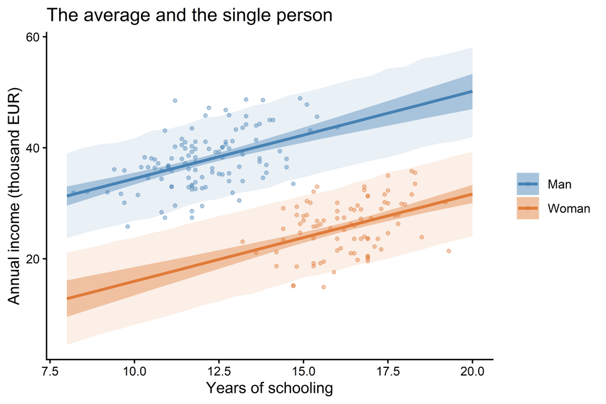

Figure 14: Expected income (line and narrow band) and predicted income (wide band), both 90 percent intervals, from the model controlling for gender. The wide band adds the residual standard deviation, so it shows where single people fall.

```r
ggplot(bands, aes(x = education, fill = gender, colour = gender)) +
  geom_ribbon(aes(ymin = pr_lo, ymax = pr_hi), alpha = 0.12, colour = NA) +
  geom_ribbon(aes(ymin = ep_lo, ymax = ep_hi), alpha = 0.4, colour = NA) +
  geom_line(aes(y = mid), linewidth = 1) +
  geom_point(
    data = income,
    aes(x = education, y = income, colour = gender),
    inherit.aes = FALSE,
    alpha = 0.4,
    size = 1
  ) +
  scale_colour_manual(values = gender_cols) +
  scale_fill_manual(values = gender_cols) +
  theme_classic() +
  labs(
    x = "Years of schooling",
    y = "Annual income (thousand EUR)",
    colour = NULL,
    fill = NULL,
    title = "The average and the single person"
  )
```

**Expected values**, 14 years of schooling:

- a man: **40.7**, 90 percent credible interval 39.7 to 41.8
- a woman: **22.3**, from 21.1 to 23.5

**Predicted value**: one new woman with 14 years earns between **14.5 and 30.1** thousand EUR (90 percent).

## The marginal effect, before and after

**View source**

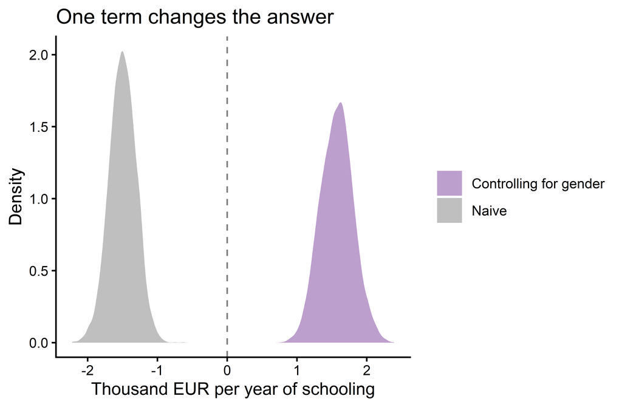

Figure 15: Posteriors of the schooling slope in both models. Without gender, the slope is negative. Holding gender constant, it is positive and slightly wider. This is Simpson’s paradox, seen in the posterior.

```r
bind_rows(
  tibble(model = "Naive", beta = beta_naive),
  tibble(model = "Controlling for gender", beta = beta_gender)
) |>
  ggplot(aes(x = beta, fill = model)) +
  geom_density(alpha = 0.5, colour = NA) +
  geom_vline(xintercept = 0, linetype = "dashed", colour = "grey50") +
  scale_fill_manual(
    values = c(Naive = "grey50", `Controlling for gender` = col_3)
  ) +
  theme_classic() +
  labs(
    x = "Thousand EUR per year of schooling",
    y = "Density",
    fill = NULL,
    title = "One term changes the answer"
  )
```

**Naive:** -1.5 per year, 90 percent interval [-1.82, -1.19].

**Controlling for gender:** comparing two people of the same gender, one more year of schooling is associated with **1.57 thousand EUR** more income, 90 percent interval [1.19, 1.96].

**100 percent** of that posterior lies above zero.

## Step 8: Limitations

- **Synthetic data:** built to show the paradox clearly, so the sizes are exaggerated.
- **The DAG may be incomplete:** ability, family background or field of study could still confound schooling and income.
- **Gender as a binary dummy:** a simplification of the measurement.
- **Additive by assumption:** one schooling slope for everyone, so the model cannot yet say whether it differs by gender.

**Note**

**A control fixes one bias, the one the DAG names.** Naming what the model still cannot rule out is part of the answer.

# Wrap-up

## Learning goals: achieved?

Table 9: The week 9 learning goals, each with its key answer and the part of the session that covers it.

| # | Learning goal | Key answer | Where |
| --- | --- | --- | --- |
| 1 | Simpson’s paradox | Gender relates to schooling and income, so the pooled slope mixes two stories and reverses | The puzzle |
| 2 | What controlling does | The slope learns only from variation the control does not share, a partial association. A dummy shifts the intercept | Venn, Dummy |
| 3 | Justify controls with a DAG | Control for confounders, not mediators, never colliders | DAGs |
| 4 | Compare models with LOO | Higher ELPD predicts new data better, and LOO does not judge the controls | Comparing models |
| 5 | A regression table | Tidy, stack, spread, `kable()` | Reporting |

## Homework and outlook

- `hw-09`: the whole workflow with a control variable, on university admissions data, due 25 November. Linked from the Schedule.
- A sample solution is published after the due date.

**Important**

**Individual feedback is only available through the opt-in path.** To opt in, add an open-source `license.md` to your submission repo **and** mark your finished homework with a commit whose message is `final submission`.

**Next week:** does schooling pay off **equally** for women and men? That question needs the lines of Figure 10 to stop being parallel: **interactions**.

## References

Kennedy, Peter E. 1981. “The ‘Ballentine’: A Graphical Aid for Econometrics.” *Australian Economic Papers* 20 (37): 414–16.

McElreath, Richard. 2020. “The Haunted DAG and the Causal Terror.” In *Statistical Rethinking: A Bayesian Course with Examples in r and STAN*, 2nd ed. Chapman; Hall/CRC. https://doi.org/10.1201/9780429029608.

Pearl, Judea, Madelyn Glymour, and Nicholas P Jewell. 2016. *Causal Inference in Statistics: A Primer*. John Wiley & Sons.

Simpson, Edward H. 1951. “The Interpretation of Interaction in Contingency Tables.” *Journal of the Royal Statistical Society: Series B (Methodological)* 13 (2): 238–41.

Vehtari, Aki, Andrew Gelman, and Jonah Gabry. 2017. “Practical Bayesian Model Evaluation Using Leave-One-Out Cross-Validation and WAIC.” *Statistics and Computing* 27 (5): 1413–32. https://doi.org/10.1007/s11222-016-9696-4.

# Appendix

## Appendix: how large the reversal is

If income truly depends on schooling $x_1$ and gender $x_2$, a model with schooling alone finds, in large samples,

$$\beta^{\text{pooled}} = \beta_1 + \beta_2 \cdot \frac{\operatorname{Cov}(\mathbf{x}_1, \mathbf{x}_2)}{\operatorname{Var}(\mathbf{x}_1)}
\tag{6}$$

The second term is the **omitted variable bias**: the gender gap $\beta_2$, times how much the share of women rises per year of schooling.

For our data, with least-squares values: $1.62 + (-18.77) \times 0.166 = -1.5$, which is the pooled slope of -1.5 in Figure 1.

The bias is large because both factors are: a big gap, and a strong link between gender and schooling. A control matters only where **both** of its arrows in the DAG are strong.

## Drawing a DAG in Quarto

For your homework, Quarto draws DAGs from a `{mermaid}` block, with no R package needed:

````markdown
```{mermaid}
flowchart LR
  G[Gender] --> E[Schooling]
  G --> I[Income]
  E --> I
```
````

- `flowchart LR` draws left to right, `TD` top down.
- Each `-->` is one arrow of your theory.
- Reference: [Quarto diagrams](https://quarto.org/docs/authoring/diagrams.html).